# Project

Super store anlysis Group Members: Ryan Harrison Course: Is 2053 Date: 05/07/2025

```python
import pandas as pd
import numpy as np
import matplotlib.pyplot as plt
import seaborn as sns
```

LOADING THE DATA We are using a sample Superstore sales dataset to explore trends in revenue, profitability, and customer segmentation.

```python
## Update the file_path variable if necessary
file_path = 'C:/Users/rzomb/OneDrive/Desktop/Data Project/Superstore.csv'
data = pd.read_csv(file_path, encoding='latin1')

## Load the dataset
df = pd.read_csv(file_path, encoding='latin1')
df.head()
```

|  | Row ID | Order ID | Order Date | Ship Date | Ship Mode | Customer ID | Customer Name | Segment | Country | City | ... | Postal Code | Region | Product ID | Category | Sub-Category | Product Name | Sales | Quantity | Discount | Profit |
| --- | --- | --- | --- | --- | --- | --- | --- | --- | --- | --- | --- | --- | --- | --- | --- | --- | --- | --- | --- | --- | --- |
| 0 | 1 | CA-2016-152156 | 11/8/2016 | 11/11/2016 | Second Class | CG-12520 | Claire Gute | Consumer | United States | Henderson | ... | 42420 | South | FUR-BO-10001798 | Furniture | Bookcases | Bush Somerset Collection Bookcase | 261.9600 | 2 | 0.00 | 41.9136 |
| 1 | 2 | CA-2016-152156 | 11/8/2016 | 11/11/2016 | Second Class | CG-12520 | Claire Gute | Consumer | United States | Henderson | ... | 42420 | South | FUR-CH-10000454 | Furniture | Chairs | Hon Deluxe Fabric Upholstered Stacking Chairs,... | 731.9400 | 3 | 0.00 | 219.5820 |
| 2 | 3 | CA-2016-138688 | 6/12/2016 | 6/16/2016 | Second Class | DV-13045 | Darrin Van Huff | Corporate | United States | Los Angeles | ... | 90036 | West | OFF-LA-10000240 | Office Supplies | Labels | Self-Adhesive Address Labels for Typewriters b... | 14.6200 | 2 | 0.00 | 6.8714 |
| 3 | 4 | US-2015-108966 | 10/11/2015 | 10/18/2015 | Standard Class | SO-20335 | Sean O'Donnell | Consumer | United States | Fort Lauderdale | ... | 33311 | South | FUR-TA-10000577 | Furniture | Tables | Bretford CR4500 Series Slim Rectangular Table | 957.5775 | 5 | 0.45 | -383.0310 |
| 4 | 5 | US-2015-108966 | 10/11/2015 | 10/18/2015 | Standard Class | SO-20335 | Sean O'Donnell | Consumer | United States | Fort Lauderdale | ... | 33311 | South | OFF-ST-10000760 | Office Supplies | Storage | Eldon Fold 'N Roll Cart System | 22.3680 | 2 | 0.20 | 2.5164 |

5 rows × 21 columns

```python
## Check for missing values in data
data.isnull().sum()

##drop rows with missing values
data.dropna(inplace=True)

## Get basic stats of data
data.describe()
```

[output not shown]

Business Questions to Answer: Which products have the highest sales and profit? Which regions generate the most sales and profit? How do sales trends vary over time?

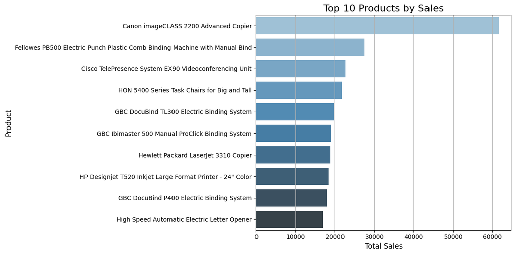

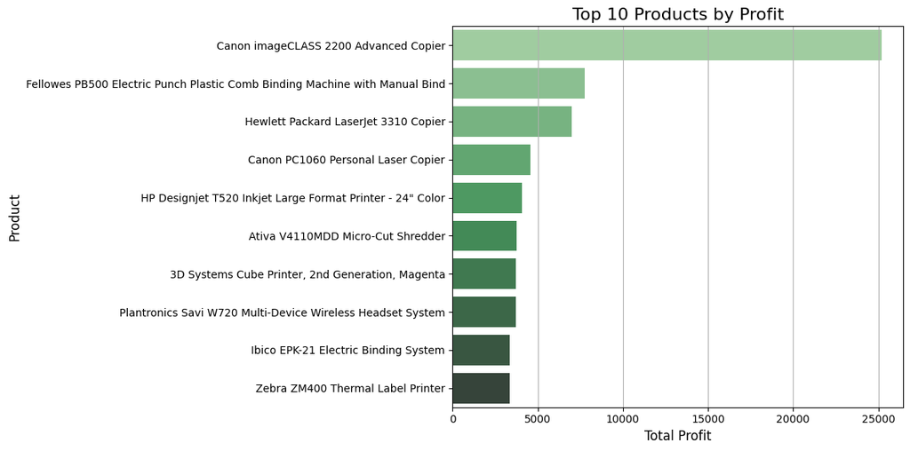

```python
##############This shows which products are the best sellers and which generate the most profit. Sometimes, best-selling products don’t have the highest profit margins


## Group by product and sum sales and profit

top_products = data.groupby('Product Name')[['Sales', 'Profit']].sum()

## Sort by sales and profit
top_sales = top_products.sort_values(by='Sales', ascending=False).head(10)
top_profit = top_products.sort_values(by='Profit', ascending=False).head(10)

## Top 10 products by Sales
plt.figure(figsize=(12,6))
sns.barplot(x=top_sales['Sales'], y=top_sales.index, palette='Blues_d')
plt.title('Top 10 Products by Sales', fontsize=16)
plt.xlabel('Total Sales', fontsize=12)
plt.ylabel('Product', fontsize=12)
plt.grid(axis='x')
plt.tight_layout()
plt.show()

## Top 10 products by Profit
plt.figure(figsize=(12,6))
sns.barplot(x=top_profit['Profit'], y=top_profit.index, palette='Greens_d')
plt.title('Top 10 Products by Profit', fontsize=16)
plt.xlabel('Total Profit', fontsize=12)
plt.ylabel('Product', fontsize=12)
plt.grid(axis='x')
plt.tight_layout()
plt.show()
```

🔹 Q1: Which products have the highest sales and profit? 📌 Analysis: You grouped data by Product Name and calculated total sales and profit, then visualized the top 10 products by each.

Canon imageCLASS 2200 Advanced Copier

Fellowes PB500 Electric Punch

Top-profit products were similar but not identical:

Copiers, phones, and machines generally topped the list for profitability.

Some high-selling items had low or negative profits, indicating low margins or discounting issues.

Not all bestsellers are profitable — the business should evaluate margins before pushing volume-heavy products.

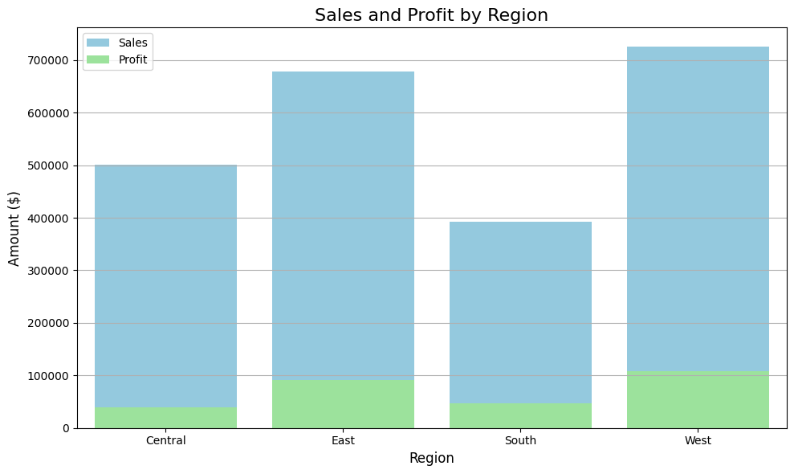

```python
######################### Which regions generate the most sales and profit?
region_data = data.groupby('Region')[['Sales', 'Profit']].sum()

## Reset the index of region_data to create region_data_reset
region_data_reset = region_data.reset_index()

plt.figure(figsize=(10,6))
sns.barplot(x='Region', y='Sales', data=region_data_reset, color='skyblue', label='Sales')
sns.barplot(x='Region', y='Profit', data=region_data_reset, color='lightgreen', label='Profit')
plt.title('Sales and Profit by Region', fontsize=16)
plt.xlabel('Region', fontsize=12)
plt.ylabel('Amount ($)', fontsize=12)
plt.legend()
plt.grid(axis='y')
plt.tight_layout()
plt.show()
```

1. The West Region Outperforms All Others Sales and profit are both highest in the West, suggesting:

Strong market demand

Efficient operations (possibly better shipping/logistics)

Product-market fit with high-margin items

The West is likely a strategic stronghold for this company.

2. The East Region is Also a Strong Performer The East ranks second in both metrics.

This region presents a stable growth opportunity, especially if marketing or delivery channels are strengthened.

Higher operational costs

Possibly heavier discounting or returns

Suboptimal product mixes (low-margin items selling more)

Potential causes:

High shipping or return costs

Poor market penetration

Excessive discounting or promotion of unprofitable products

Needs a targeted diagnostic: logistics, customer satisfaction, or localized pricing strategies might be failing.

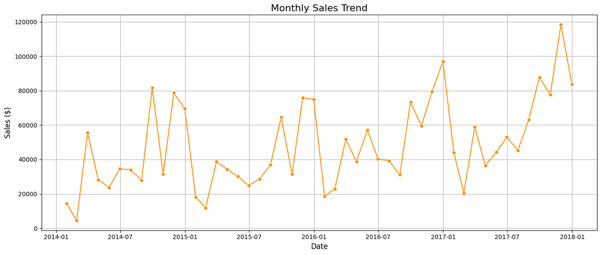

```python
data['Order Date'] = pd.to_datetime(data['Order Date'])

# Group by month/year
monthly_sales = data.set_index('Order Date').resample('M').sum()

# Plot sales trend over time
plt.figure(figsize=(14,6))
sns.lineplot(x=monthly_sales.index, y=monthly_sales['Sales'], marker='o', color='darkorange')
plt.title('Monthly Sales Trend', fontsize=16)
plt.xlabel('Date', fontsize=12)
plt.ylabel('Sales ($)', fontsize=12)
plt.grid(True)
plt.tight_layout()
plt.show()
```

This shows whether there’s seasonality or growth in sales over time. It's great for forecasting and planning. There is a clear upward trend in sales over the time period covered.

Sales spike toward year-end, particularly in November and December, which suggests seasonal shopping trends (likely holidays).

Conclusion: The business experiences seasonal surges in Q4 — plan inventory, staffing, and marketing accordingly.